# Relationships between two quantitative variables (Sections 2.5-2.6)

Day 7

Claire Kelling

Carleton College  
STAT 120 - Fall 2026

## Question of the Day

Are you more of a morning person or night owl?

## Today’s Topics

**Logistics:**

- Short report (assignment and groups) and Quiz 1 Study guide are posted!
- Save your code often in Maize! (Maize troubleshooting: reach out to me!)
- HW Regrade Requests: please submit within a week (if you think something was inaccurately graded)

**Topics covered today:**

- Finishing up Quantitative Variable summaries
- Relationships between two quantitative variables (Section 2.5-2.6)
  - Graphically, Numerically (correlation)

# Two Quantitative Variables

## Two Quantitative Variables

So far: **univariate** data (1 variable) or sometimes comparing quantitative data by category.

**Bivariate Data**: each case $i$ has **two** measurements

- $x_i$ is **explanatory** variable value for case (row) $i$
- $y_i$ is the **response** variable value for case (row) $i$
- (Independent vs dependent variables)

## Example: NBA Wingspan and Shot-Blocking

Source: SCORE Sports Data Repository (data.scorenetwork.org), compiled from Basketball-Reference.com and CraftedNBA.com

## Example: NBA Wingspan and Shot-Blocking

Data format:

- wingspan_inches: player’s wingspan, in inches
- blk: blocks per 100 possessions

```r
nba <- read.csv("https://data.scorenetwork.org/data/nba_wingspan_performance_2025.csv")
nba <- nba %>% filter(mp > 200)  # drop players with very limited playing time
head(nba[ , c("name", "wingspan_inches", "blk")])
```

```
           name wingspan_inches blk
1    AJ Johnson           80.50 0.2
2  Aaron Gordon           83.75 0.5
3 Aaron Holiday           79.50 0.7
4 Aaron Nesmith           82.00 0.7
5 Aaron Wiggins           81.75 0.5
6     Adem Bona           87.75 3.8
```

## Example: NBA Wingspan Analysis

Univariate Exploratory Data Analysis (EDA)

- **Univariate**: one variable

```r
summary(nba[ , c("wingspan_inches", "blk")])
```

```
 wingspan_inches      blk
 Min.   :73.00   Min.   :0.000
 1st Qu.:80.00   1st Qu.:0.500
 Median :82.50   Median :0.800
 Mean   :82.60   Mean   :1.026
 3rd Qu.:85.12   3rd Qu.:1.400
 Max.   :96.00   Max.   :5.600
```

# Scatterplot

## Graphically: Describing associations between two quantitative variables

- **Scatterplot:** for each case, plot $(x_i, y_i)$
- Analysis:
  - **Form?** linear, curved, “clumpy”, …
  - **Direction?** positive, negative, none, both
  - **Strength?** amount of variation in $y$ around a “trend” (weak, strong)

## Scatterplot Example

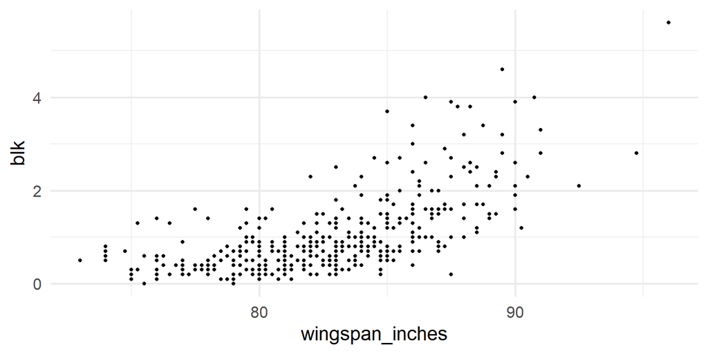

```r
ggplot(nba, aes(x = wingspan_inches, y = blk)) +
  geom_point()+
  theme_minimal(base_size = 20)
```

**Form, direction, strength?**

## Scatterplot Example

Add labels to ggplot:

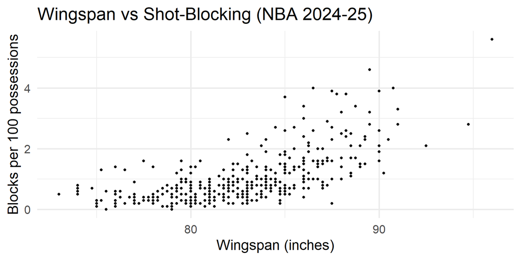

```r
ggplot(nba, aes(x = wingspan_inches, y = blk)) +
  geom_point() +
  labs(x = "Wingspan (inches)",
       y = "Blocks per 100 possessions",
       title = "Wingspan vs Shot-Blocking (NBA 2024-25)")+
  theme_minimal(base_size = 20)
```

## Scatterplot: Direction

**Definitions**

- **Positive association**: values of $y$ tend to be higher when $x$ values are higher
- **Negative association**: values of $y$ tend to be lower when $x$ values are higher
- Positive, Negative, None, or Both?

**Q1:** $x$ is amount of fertilizer used on a crop, $y$ is crop yield: Positive, Negative, None, or Both?

- Positive (or both?): the more fertilizer used, the greater the yield of the crop, up to a certain point.

**Q2:** $x$ is number of cigarettes smoked per day, $y$ is lung capacity

- Negative: the more cigarettes smoked, the lower the lung capacity.

# Numeric summaries

## Relationships between Quantitative Variables

**Numerically**

If the relationship is **linear**:

- **Correlation:** strength, direction
- **Linear regression:** models the association

## Correlation

**Definition**

**Correlation Coefficient**: denoted $r$ (sample) or $\rho$ (population)

**Strength** of *linear* association:

- $r$ $\approx \pm 1$: strong
- $r$ $\approx 0$: weak

**Direction** of *linear* association: ($-1\leq r \leq 1$)

- $r$ $> 0$: positive
- $r$ $< 0$: negative

Correlation has **no measurement units**

Just a scale to gauge strength of **linear** association

## Correlation

**R code**

```r
cor(data$x, data$y)
```

Order of $x$ and $y$ doesn’t matter *for this function*

## Example: NBA Wingspan and Shot-Blocking

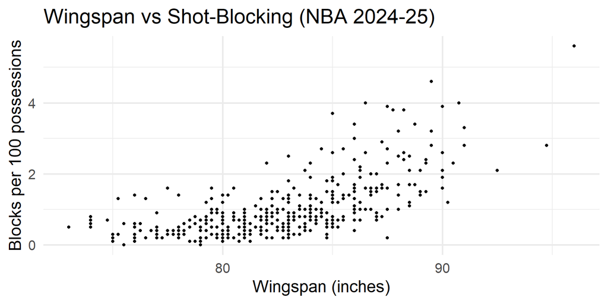

```r
cor(nba$wingspan_inches, nba$blk, use = "complete.obs")
```

```
[1] 0.6598489
```

- Moderate-to-strong positive association
- But, we should **look at the scatterplot**
- We need to look for curvature ($r$ is not appropriate!) or outliers

## Example: Textbook survey data

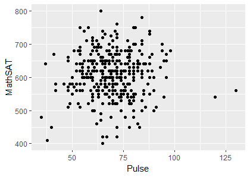

```r
cor(survey$MathSAT,
        survey$Pulse)
```

```
[1] 0.04131351
```

- No linear association between pulse rate and math SAT score!
- Note the two “unusual points” with pulse rates around 120

# Regression

## Linear Scatterplots: Adding trend lines

**Linear Regression:** describes a method of modeling $y$ as a **linear** function of $x$

[figure not shown]

- Least Squares Method: a line which minimizes the **squared vertical distances** between the responses and the line

```r
ggplot(nba, aes(x = wingspan_inches, y = blk)) +
  geom_point() +
  geom_smooth(method = "lm", se = FALSE) +
  labs(x = "Wingspan (inches)",
       y = "Blocks per 100 possessions",
       title = "Wingspan vs Shot-Blocking (NBA 2024-25)")
```

## Regression Line: Regressing $y$ on $x$

**Regression of $y$ on $x$**: estimated (sample) line

$$\hat{y} = a + bx$$

- $\hat{y}$ is the **predicted** value of $y$ at $x$
- $y - \hat{y}$ is the **residual** value of $y$ at $x$
  - measures difference, or “error”, between observed and predicted
  - **least squares** method picks a line that makes $\sum_{i=1}^n (y_i-\hat{y}_i)^2$ as small as possible

## Example: NBA Wingspan and Shot-Blocking

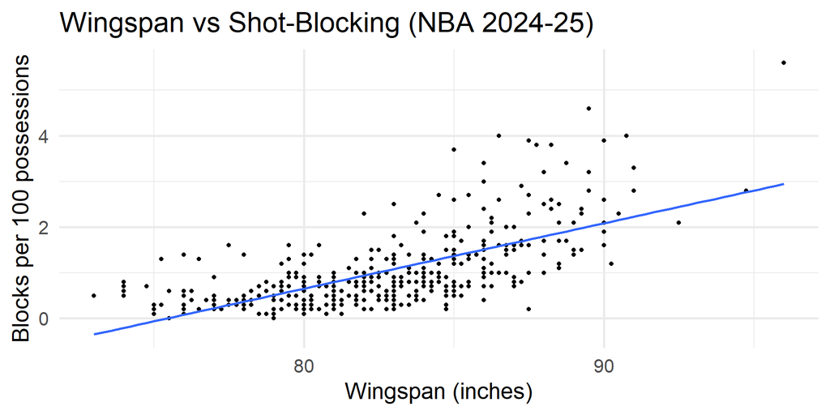

## Example: NBA Wingspan and Shot-Blocking

- $\widehat{blk} = a + b(\text{wingspan})$
- From the regression line:
  - $a =$ $-10.81$ (intercept)
  - $b =$ $0.143$ (slope)
- $\widehat{blk} = -10.81 + 0.143(\text{wingspan})$
- **predicted value** of blocks per 100 possessions at a wingspan of 96 inches?
- $\widehat{blk} = -10.81 + 0.143 (96) = 2.918$ blocks per 100 possessions

## Example: NBA Wingspan and Shot-Blocking

- Calculate the **residual** (error)
- Victor Wembanyama has a 96-inch wingspan and blocks 5.6 shots per 100 possessions
- How do we calculate the residual?
- $blk - \widehat{blk} = 5.6-2.918 = 2.682$ blocks per 100 possessions
- Wembanyama blocks 2.682 *more* shots per 100 possessions than his wingspan alone predicts

# Interpretation

## How do we interpret $a$ and $b$?

$$\hat{y} = a + bx$$

- **b**: **slope**, increase in predicted $y$ ($\hat{y}$) for every unit increase in x
  - Defined as the *rise in $y$* over the *run in x*
  - $b = \frac{\text{change in }\hat{y}}{\text{change in }x}$
- **a**: **intercept**, predicted $y$ value ($\hat{y}$) when $x = 0$
  - $\hat{y} = a + b(0) = a$

How can you label these on the graph?

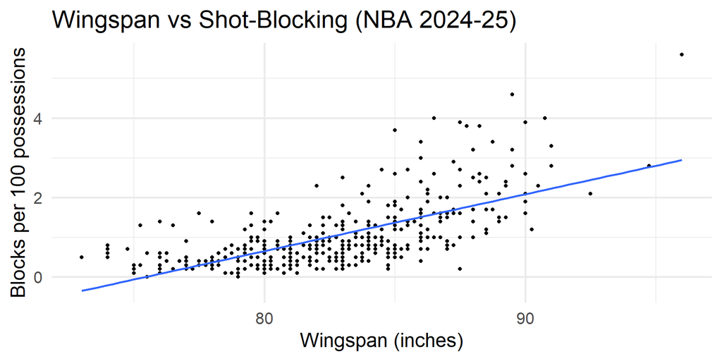

## Finding $a$ and $b$ in R

The *lm()* command in R runs a **linear model** (linear regression)

```r
nba_lm <- lm(blk ~ wingspan_inches, data = nba)
nba_lm
```

```
Call:
lm(formula = blk ~ wingspan_inches, data = nba)

Coefficients:
    (Intercept)  wingspan_inches
       -10.8053           0.1432
```

## Finding $a$ and $b$ in R

The linear model also has measures of **uncertainty** associated with the estimates of $a$ and $b$

```r
summary(nba_lm)
```

```
Call:
lm(formula = blk ~ wingspan_inches, data = nba)

Residuals:
     Min       1Q   Median       3Q      Max
-1.52737 -0.42236 -0.08153  0.25799  2.65517

Coefficients:
                  Estimate Std. Error t value Pr(>|t|)
(Intercept)     -10.805310   0.687383  -15.72   <2e-16 ***
wingspan_inches   0.143231   0.008312   17.23   <2e-16 ***
---
Signif. codes:  0 '***' 0.001 '**' 0.01 '*' 0.05 '.' 0.1 ' ' 1

Residual standard error: 0.633 on 385 degrees of freedom
Multiple R-squared:  0.4354,    Adjusted R-squared:  0.4339
F-statistic: 296.9 on 1 and 385 DF,  p-value: < 2.2e-16
```

## Interpretation of $a$ and $b$

$$\widehat{blk} = -10.81 + 0.143(\text{wingspan})$$

**Interpretation of $a = -10.81$:**

At a wingspan of 0 inches, we predict -10.81 blocks per 100 possessions **BUT**

- we don’t have any players with a wingspan anywhere close to 0 (our data only spans 73 to 96 inches). Therefore, **we cannot interpret this in context** — it’s extrapolating far outside the data.
- it is not realistic to have wingspan = 0
- the relationship is **not linear**!!!!

**Interpretation of $b = 0.143$:**

An increase of 1 inch of wingspan results in an *estimated* **increase** in blocks per 100 possessions of 0.143.

**Scaled:** An increase of 7 inches of wingspan (roughly the gap between an average guard and an average center) results in an *estimated* **increase** of about 1 block per 100 possessions.

## Example: Regressing grade on study hours

Regressing grade on study hours

**Q1**: What is $y$ and what is $x$?

- $y$: grade
- $x$: study hours

## Example: Regressing grade on study hours

$$\widehat{grade} = 50 + 3 \times hours$$

**Q**: Interpret the slope *in context*:

1. Predicted grade goes up by 1 point for a person who studies 3 more hours.
2. Predicted grade goes up by 3 points for a person who studies 1 more hour.
3. Three more hours of studying gives 3 more points on the final.
4. The response variable goes up by 3 if the explanatory variable goes up by 1.

## Example: Regressing grade on study hours

$$\widehat{grade} = 50 + 3 \times hours$$

**Q**: Interpret the slope *in context*:

1. Predicted grade goes up by 1 point for a person who studies 3 more hours.

**(b) Predicted grade goes up by 3 points for a person who studies 1 more hour.**

3. Three more hours of studying gives 3 more points on the final.
4. The response variable goes up by 3 if the explanatory variable goes up by 1.

## Example: Regressing grade on study hours

$$\widehat{grade} = 50 + 3 \times hours$$

**Q**: Interpret the intercept *in context*:

1. If a person doesn’t study at all, the predicted grade will be 50.
2. A predicted grade of zero goes with studying 50 hours.
3. The more someone studies, the higher the predicted grade.
4. The response variable is 50 if the explanatory variable is 0.

## Example: Regressing grade on study hours

$$\widehat{grade} = 50 + 3 \times hours$$

**Q**: Interpret the intercept *in context*:

**(a) If a person doesn’t study at all, the predicted grade will be 50.**

2. A predicted grade of zero goes with studying 50 hours.
3. The more someone studies, the higher the predicted grade.
4. The response variable is 50 if the explanatory variable is 0.

***With a condition that the data has cases with H=0 hours.

## Next Class

Continuing with Bivariate Relationships